# Identifying bot session

Aim - From a set of session features, identify which are coming from humans and which are coming from bots.

Input - The two CSV tables containing the sesions features (including "request interarrival time", "request interarrival time" and "number of sessions") as computed and written by the notebook `ComputeFeatures.ipynb`.

Output - Separation of the clients, presumably between humans and bots.

Tools - SparkSQL and SparkML from Spark 2.4.3, pandas 0.24.2, matplotlib 2.2.2

**Table of content**

- Initialisation
- Read the features
- Average the features
- Pre-process and format the features
- Clustering
- Discussion with plots of the clusters

## Initialisation

```python
from pyspark.ml.clustering import KMeans
from pyspark.ml.feature import VectorAssembler
from pyspark.ml.feature import Normalizer
from pyspark.ml.evaluation import ClusteringEvaluator
from pyspark.sql import SparkSession
from pyspark.sql.functions import *
from pyspark.sql.types import StructType, StructField, StringType, LongType, BooleanType
import pandas as pd
import matplotlib.pyplot as plt
```

```python
spark = SparkSession.builder.config('spark.driver.memory','8G').getOrCreate()
spark
```

**SparkSession - in-memory**

**SparkContext**

[Spark UI](http://192.168.0.31:4040)

**Version**

`v2.4.3`

**Master**

`local[*]`

**AppName**

`pyspark-shell`

## Read the features

Read the features from the CSV files.

```python
input_directory = './requests.csv.d'

keys_type = [( 'client',                    StringType()  ),
             ( 'timestamp_utc',             LongType()    ),
             ( 'first_connection',          BooleanType() ),
             ( 'new_session',               BooleanType() ),
             ( 'session_number',            LongType()    ),
             ( 'request_interarrival_time', LongType()    )
            ]

schema = StructType([StructField(key, ktype, True) for key,ktype in keys_type])
requests = spark.read.option('header','true').schema(schema).csv(input_directory)
```

```python
input_directory = './sessions.csv.d'

keys_type = [( 'client',                    StringType()  ),
             ( 'timestamp_utc',             LongType()    ),
             ( 'first_session',             BooleanType() ),
             ( 'session_number',            LongType()    ),
             ( 'number_of_requests',        LongType()    ),
             ( 'session_interarrival_time', LongType()    )
            ]

schema = StructType([StructField(key, ktype, True) for key,ktype in keys_type])
sessions = spark.read.option('header','true').schema(schema).csv(input_directory)
```

## Average the features

Compute the average of the features for each client.  
In addition to the three features of the paper, the total number of sessions is added to the list of features.

```python
avg_ss = sessions.where(col('session_interarrival_time').isNotNull()) \
                 .groupBy('client')                                   \
                 .agg({'number_of_requests':'mean',
                       'session_interarrival_time':'mean',
                       'session_number':'max'})                       \
                 .withColumnRenamed('avg(number_of_requests)', 'avg_number_of_requests')               \
                 .withColumnRenamed('avg(session_interarrival_time)', 'avg_session_interarrival_time') \
                 .withColumnRenamed('max(session_number)', 'total_number_of_sessions')

avg_rq = requests.where(col('request_interarrival_time').isNotNull()) \
                 .groupBy('client')                                   \
                 .mean('request_interarrival_time')                   \
                 .withColumnRenamed('avg(request_interarrival_time)', 'avg_request_interarrival_time')

avg_ft = avg_ss.join(avg_rq, on='client', how='inner')
```

## Pre-process and format the features

Take the log of the features because their distributions are heavy tailed (cf. result plots below).  
Replace the client by an ID number.

```python
%%time
avg_ft = avg_ft.withColumn('log_avg_number_of_requests',
                 log(col('avg_number_of_requests'))) \
               .withColumn('log_avg_session_interarrival_time',
                 log(col('avg_session_interarrival_time'))) \
               .withColumn('log_avg_request_interarrival_time',
                 log(col('avg_request_interarrival_time'))) \
               .withColumn('log_total_number_of_sessions',
                 log(col('total_number_of_sessions')))

avg_ft = avg_ft.withColumn('id', monotonically_increasing_id())

avg_ft = avg_ft.select(['id',
                        'log_avg_number_of_requests',
                        'log_avg_session_interarrival_time',
                        'log_avg_request_interarrival_time',
                        'log_total_number_of_sessions'])

avg_ft = avg_ft.where(col('log_avg_number_of_requests').isNotNull()
                    & col('log_avg_session_interarrival_time').isNotNull()
                    & col('log_avg_request_interarrival_time').isNotNull()
                    & col('log_total_number_of_sessions').isNotNull())

avg_ft.toPandas().sample(n=10).head(10)
```

```
CPU times: user 140 ms, sys: 16.1 ms, total: 156 ms
Wall time: 14.8 s
```

|  | id | log_avg_number_of_requests | log_avg_session_interarrival_time | log_avg_request_interarrival_time | log_total_number_of_sessions |
| --- | --- | --- | --- | --- | --- |
| 1182 | 154618822694 | 1.386294 | 8.451053 | 4.982984 | 2.079442 |
| 4326 | 584115552320 | 3.502550 | 15.510448 | 2.938149 | 1.791759 |
| 6526 | 884763263021 | 1.791759 | 9.742086 | 4.162782 | 0.693147 |
| 6542 | 884763263038 | 0.693147 | 16.946068 | -0.693147 | 0.693147 |
| 10895 | 1486058684469 | 0.064539 | 15.452564 | 4.905275 | 2.772589 |
| 6532 | 884763263028 | 1.098612 | 11.328365 | 2.512306 | 0.693147 |
| 9427 | 1288490188853 | 2.833213 | 11.092245 | -1.673976 | 0.693147 |
| 4223 | 575525617677 | 2.197225 | 9.655379 | 2.672505 | 1.098612 |
| 10954 | 1494648619052 | 0.693147 | 10.685218 | 0.693147 | 0.693147 |
| 6063 | 824633720861 | 0.693147 | 12.700525 | 0.000000 | 0.693147 |

Select the features that will actually be used for the clustering.

```python
include = {'log_avg_number_of_requests':        True,
           'log_avg_session_interarrival_time': True,
           'log_avg_request_interarrival_time': True,
           'log_total_number_of_sessions':      True}
selected_features = [feature
                     for feature in include.keys()
                     if include[feature]]
```

Prepare the features so that the dataframe has a correct input format for the Spark KMeans function.  
Normalise the features.

```python
assembler = VectorAssembler(inputCols=selected_features, outputCol='features')
features = assembler.transform(avg_ft).select('id', 'features')

normaliser = Normalizer(inputCol='features', outputCol='normalised_features', p=2.0)
normalised_features = normaliser.transform(features)

print(f'Number of clients: {normalised_features.count()}')
```

```
Number of clients: 12557
```

## Clustering

Construct a k-means model with two clusters, fit it to the data and add a column containing the cluster number.

```python
%%time
kmeans = KMeans(featuresCol='normalised_features', predictionCol='cluster_number').setK(2)
model = kmeans.fit(normalised_features)
clustered_features = model.transform(normalised_features)
```

```
CPU times: user 23.2 ms, sys: 6.42 ms, total: 29.6 ms
Wall time: 27.1 s
```

Compute the silhouette score of the clustering.

```python
%%time
evaluator = ClusteringEvaluator(featuresCol='normalised_features', predictionCol='cluster_number')
silhouette = evaluator.evaluate(clustered_features.select(['id','normalised_features','cluster_number']))
print(f'Silouette score of the clustering: {silhouette}\n')
```

```
Silouette score of the clustering: 0.721422829649346

CPU times: user 12.6 ms, sys: 4.29 ms, total: 16.9 ms
Wall time: 21.2 s
```

## Discussion with plots of the clusters

Re-format the features and the cluster number into a pandas dataframe.

```python
%%time
unpacked_features = avg_ft.join(clustered_features, on='id', how='inner') \
                          .select(['id']+selected_features+['cluster_number']) \
                          .toPandas()
unpacked_features.sample(n=10).head(10)
```

```
CPU times: user 91.5 ms, sys: 10.2 ms, total: 102 ms
Wall time: 19.8 s
```

|  | id | log_avg_number_of_requests | log_avg_session_interarrival_time | log_avg_request_interarrival_time | log_total_number_of_sessions | cluster_number |
| --- | --- | --- | --- | --- | --- | --- |
| 487 | 962072674346 | 0.773190 | 16.842131 | -1.945910 | 1.945910 | 1 |
| 6924 | 128849018910 | 2.590267 | 11.033162 | 3.549742 | 1.386294 | 0 |
| 5332 | 1503238553602 | 0.559616 | 16.716517 | 5.650147 | 1.609438 | 0 |
| 8939 | 773094113348 | 0.000000 | 12.255099 | 4.762174 | 1.386294 | 0 |
| 9098 | 1486058684470 | 3.433987 | 10.786656 | 2.011783 | 0.693147 | 1 |
| 3582 | 566935683113 | 1.791759 | 9.530248 | 6.420809 | 0.693147 | 0 |
| 11971 | 1606317768733 | 5.484797 | 13.361996 | 1.477809 | 1.098612 | 1 |
| 8742 | 695784702013 | 0.000000 | 11.848394 | -3.401197 | 1.098612 | 1 |
| 3775 | 343597383745 | 1.791759 | 9.943237 | -1.609438 | 0.693147 | 1 |
| 3586 | 678604832815 | 0.693147 | 15.880374 | 4.158883 | 0.693147 | 0 |

Plot of projections of the clusters.  
Two clusters are identified. The clustering mainly relies on the request interarrival time feature, with a **separation around 15 to 20 sec**.  
Since bots usually send requests at the highest possible frequency (with tricks like random time interval to avoid being detected), we suppose that the cluster with lowest request interarrival times (yellow in the html version of the notebook) is the bot cluster.  
The plots with the added feature total number of session exhibits interesting structures to investigate (like preferred constant times).

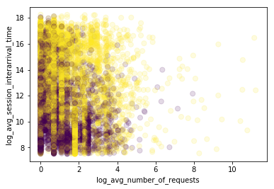

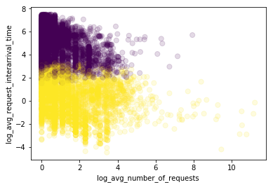

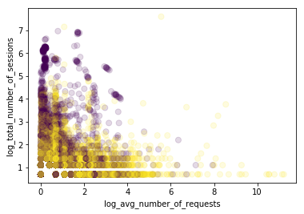

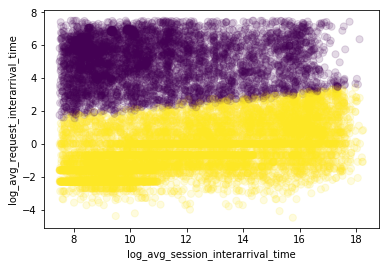

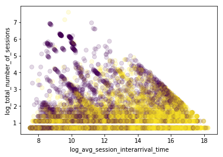

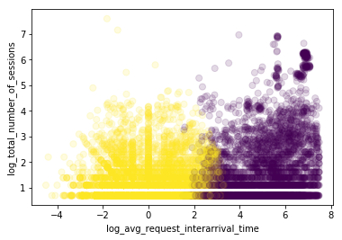

```python
for i in range(len(selected_features)):
    for j in range(i+1,len(selected_features)):
        plt.scatter(unpacked_features[selected_features[i]], unpacked_features[selected_features[j]],
                    c=unpacked_features['cluster_number'], s=50, alpha=0.15)
        plt.xlabel(selected_features[i])
        plt.ylabel(selected_features[j])
        plt.show();
```

Close the spark session.

```python
spark.stop()
```

*(end of the Identification notebook)*